# Data Tidak Stasioner

## Tidak Stasioner dalam Rataan dan Ragam

Hal ini dapat disimulasikan dengan membangkitkan data yang tidak stasioner dalam ragam lalu membentuk trend menggunakan data tersebut

```r
set.seed(8990)
sd2 <- arima.sim(n=100, list(order=c(1,0,1),ar=c(.2), ma=.2), sd = 2)
sd6 <- arima.sim(n=100, list(order=c(1,0,1),ar=c(.2), ma=.2), sd = 6)
datagab <- c(sd2,sd6)
dt_rg <- startSpot + cumsum(datagab)  |> ts()
dt_rg <- dt_rg +100
```

### Plot Time Series

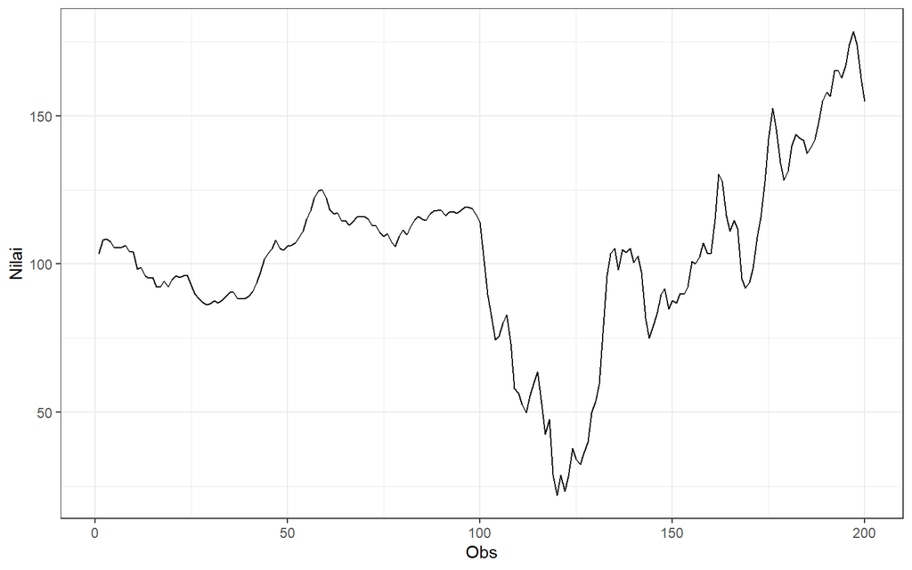

```r
dt_rg |> as_tsibble() |>
  ggplot(aes(x = index, y = value)) +
  geom_line() + theme_bw() +
  xlab("Obs") + ylab("Nilai")
```

Berdasarkan plot time series tersebut, terlihat bahwa data tidak stasioner dalam rataan, ditandai dengan adanya trend pada data dan tidak stasioner dalam ragam, ditandai dengan adanya perbedaan lebar pita pada plot

### Plot ACF

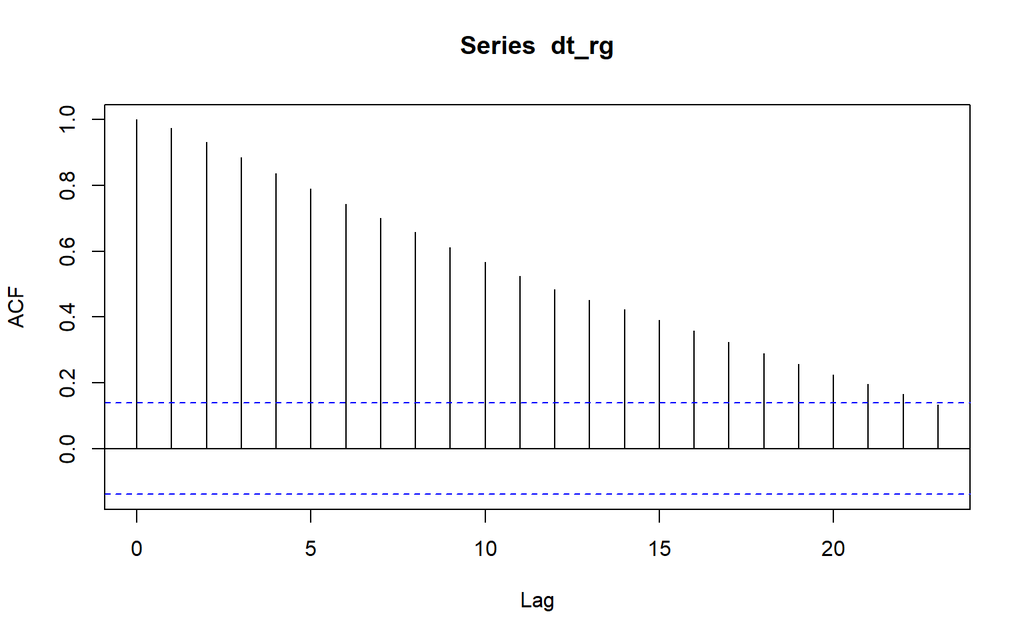

```r
acf(dt_rg)
```

Berdasarkan plot ACF, terlihat bahwa plot ACF pada data tersebut menurun secara perlahan (*tails off slowly*) yang menandakan data tidak stasioner dalam rataan

### Uji ADF

```r
adf.test(dt_rg)
```

```
##
##  Augmented Dickey-Fuller Test
##
## data:  dt_rg
## Dickey-Fuller = -1.8362, Lag order = 5, p-value = 0.6447
## alternative hypothesis: stationary
```

$H_0$ : Data tidak stasioner dalam rataan

$H_1$ : Data stasioner dalam rataan

Berdasarkan uji ADF tersebut, didapat *p-value* sebesar 0.6447 yang lebih besar dari taraf nyata 5% dan menandakan bahwa data tidak stasioner dalam rataan. Hal ini sesuai dengan hasil eksplorasi menggunakan plot time series dan plot ACF.

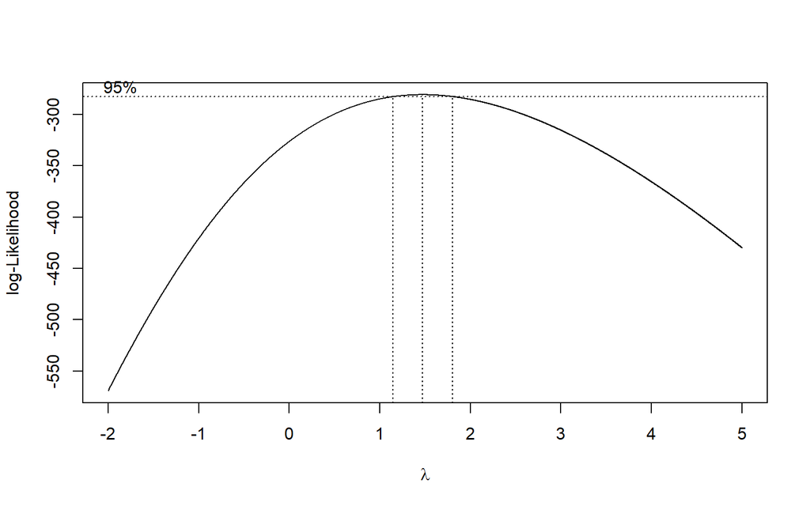

```r
index <- seq(1:200)

# Uji Box-Cox
bc <- boxcox(
  dt_rg ~ index,
  lambda = seq(-2, 5, by = 0.001)
)
```

```r
# Nilai lambda optimum (dibulatkan)
lambda <- bc$x[which.max(bc$y)]
lambda
```

```
## [1] 1.47
```

```r
# Selang kepercayaan 95% untuk lambda
ci_lambda <- bc$x[bc$y > max(bc$y) - 0.5 * qchisq(0.95, 1)]

# Batas bawah dan batas atas
ci_lower <- min(ci_lambda)
ci_upper <- max(ci_lambda)

c(Batas_Bawah = ci_lower, Batas_Atas = ci_upper)
```

```
## Batas_Bawah  Batas_Atas
##       1.148       1.805
```

differencing

```r
# Differencing pertama pada postrend
dt_rg_diff1 <- diff(dt_rg, differences = 1)
```

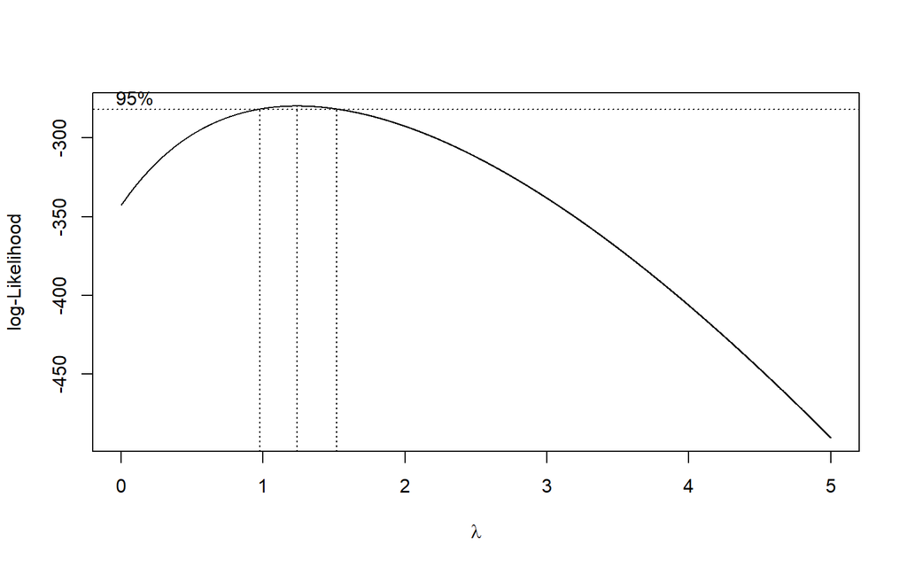

```r
index <- seq(1:199)

# Uji Box-Cox
bc <- boxcox(
  dt_rg_diff1 - min(dt_rg_diff1) + 1 ~ index,
  lambda = seq(0, 5, by = 0.001)
)
```

```r
# Nilai lambda optimum (dibulatkan)
lambda <- bc$x[which.max(bc$y)]
lambda
```

```
## [1] 1.238
```

```r
# Selang kepercayaan 95% untuk lambda
ci_lambda <- bc$x[bc$y > max(bc$y) - 0.5 * qchisq(0.95, 1)]

# Batas bawah dan batas atas
ci_lower <- min(ci_lambda)
ci_upper <- max(ci_lambda)

c(Batas_Bawah = ci_lower, Batas_Atas = ci_upper)
```

```
## Batas_Bawah  Batas_Atas
##       0.978       1.517
```

### Partisi Data

#### Bagian 1

```r
dt_rg1 <- dt_rg[1:66] |> ts()
mean(dt_rg1)
```

```
## [1] 101.2441
```

```r
var(dt_rg1)
```

```
## [1] 118.5542
```

#### Plot Time Series

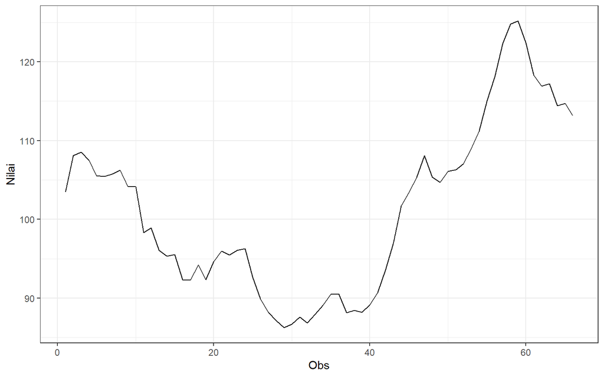

```r
dt_rg1 |> as_tsibble() |>
  ggplot(aes(x = index, y = value)) +
  geom_line() + theme_bw() +
  xlab("Obs") + ylab("Nilai")
```

Berdasarkan plot time series tersebut, terlihat bahwa data tidak stasioner dalam rataan karena masih terdapat tren pada data, namun cenderung stasioner dalam ragam karena memiliki lebar pita yang cenderung sama

#### Plot ACF

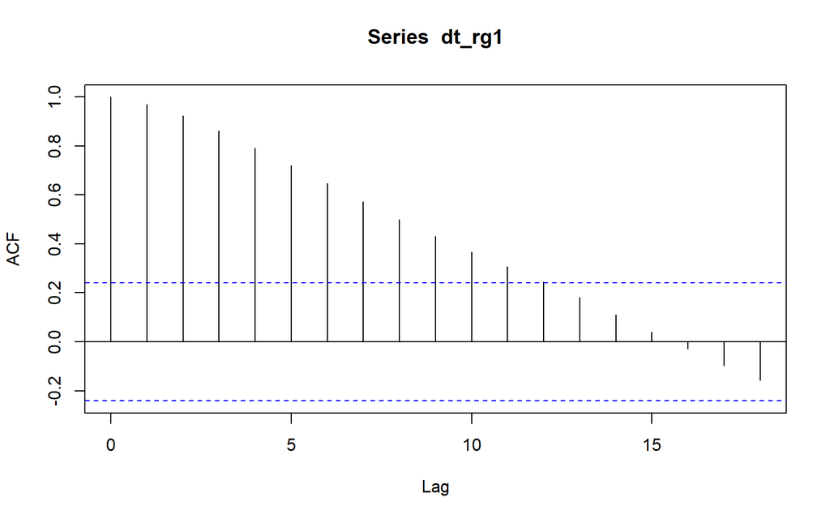

```r
acf(dt_rg1)
```

Berdasarkan plot ACF, terlihat bahwa plot ACF pada data tersebut menurun secara perlahan (*tails off slowly*) yang menandakan data tidak stasioner dalam rataan

#### Uji ADF

```r
adf.test(dt_rg1)
```

```
##
##  Augmented Dickey-Fuller Test
##
## data:  dt_rg1
## Dickey-Fuller = -1.7373, Lag order = 4, p-value = 0.6816
## alternative hypothesis: stationary
```

$H_0$ : Data tidak stasioner dalam rataan

$H_1$ : Data stasioner dalam rataan

Berdasarkan uji ADF tersebut, didapat *p-value* sebesar 0.6816 yang lebih besar dari taraf nyata 5% dan menandakan bahwa data tidak stasioner dalam rataan. Hal ini sesuai dengan hasil eksplorasi menggunakan plot time series dan plot ACF

#### Bagian 2

```r
dt_rg2 <- dt_rg[67:150] |> ts()
mean(dt_rg2)
```

```
## [1] 87.36297
```

```r
var(dt_rg2)
```

```
## [1] 913.2413
```